# The Sound of a Decade: Multi-Platform Chart-History Analysis of Chinese Popular Music, 2018-2024

HKU COMP2501 Project Report

October 02, 2026

# 1 1. Introduction

We track whether QQ Music’s seven public toplists – Hot Songs (热歌榜), Online Songs (网络歌曲榜), Mainland (内地榜), Rap (说唱榜), EDM (电音榜), Guofeng (国风热歌榜), and Douyin Hit (抖音热歌榜) – shifted in a measurable way across 2018-2024. We use only the data that QQ’s public musicu.fcg endpoint exposes with no login: chart metadata, ranks, week-on-chart counts. **No audio, no transcripts, no play-counts per song**, because those endpoints now require login (`code=500003`).

The original proposal listed “2015-2025”. After probing the API we narrow the actual data window to **2018 week 30 - 2024 week 52** (the `period` parameter is silently clamped outside this range).

# 2 2. Data

## 2.1 2.1 Toplists and coverage

Seven QQ toplists are pulled, each with weekly issues from 2018W30 to 2024W52 (some start later because of topId-specific data availability):

| topId | Title | Issues | Unique songs | Genre tag |
| --- | --- | --- | --- | --- |
| 26 | 热歌榜 | 202 | 1942 | - |
| 28 | 网络歌曲榜 | 331 | 9626 | - |
| 5 | 内地榜 | 288 | 10928 | - |
| 58 | 说唱榜 | 195 | 3125 | rap |
| 57 | 电音榜 | 191 | 2878 | edm |
| 65 | 国风热歌榜 | 194 | 1303 | guofeng |
| 60 | 抖音热歌榜 | 167 | 1729 | - |

Total ~137,000 song-week rows after collapsing the long sheet into `song_year_all`.

| top_title | year | weeks_recorded | songs |
| --- | --- | --- | --- |
| 内地 | 2018 | 4 | 255 |
| 内地榜 | 2018 | 18 | 646 |
| 内地榜 | 2019 | 51 | 1868 |
| 内地榜 | 2020 | 43 | 1644 |
| 内地榜 | 2021 | 43 | 1552 |
| 内地榜 | 2022 | 43 | 1814 |
| 内地榜 | 2023 | 43 | 1722 |
| 内地榜 | 2024 | 43 | 1701 |
| 国风热歌榜 | 2020 | 23 | 339 |
| 国风热歌榜 | 2021 | 43 | 475 |
| 国风热歌榜 | 2022 | 43 | 395 |
| 国风热歌榜 | 2023 | 42 | 312 |

## 2.2 2.2 Per-song-per-year summary

| year | song_id | song_title | singer_name | album_mid | top_ids_present | weeks_total | peak_rank_min | mean_rank_avg | genres |
| --- | --- | --- | --- | --- | --- | --- | --- | --- | --- |
| 2018 | 8145 | 遇见 | 孙燕姿 | 002ehzTm0TxXC2 | 1 | 14 | 83 | 92.78571 | unknown |
| 2018 | 8798 | 圣诞结 | 陈奕迅 | 003Z5p2o40ZnnR | 1 | 1 | 46 | 46.00000 | unknown |
| 2018 | 13413 | 说爱你 | 蔡依林 | 000q5U9S2OLNg4 | 1 | 5 | 12 | 23.40000 | unknown |
| 2018 | 96319 | 旅行 | 许巍 | 000lrk6m1fk7tl | 1 | 1 | 40 | 40.00000 | unknown |
| 2018 | 97773 | 晴天 | 周杰伦 | 000MkMni19ClKG | 1 | 13 | 87 | 93.23077 | unknown |
| 2018 | 153811 | 一起走过的日子 | 刘德华 | 001MYVwe23zYvz | 1 | 1 | 34 | 34.00000 | unknown |
| 2018 | 184628 | 该死的温柔 | 马天宇 | 000mtyRr43VBPu | 1 | 5 | 20 | 42.40000 | unknown |
| 2018 | 264703 | 爱的故事 (上集) | 孙耀威 | 0044qN8G3hm2FM | 1 | 1 | 71 | 71.00000 | unknown |

# 3 3. Cross-chart correlation

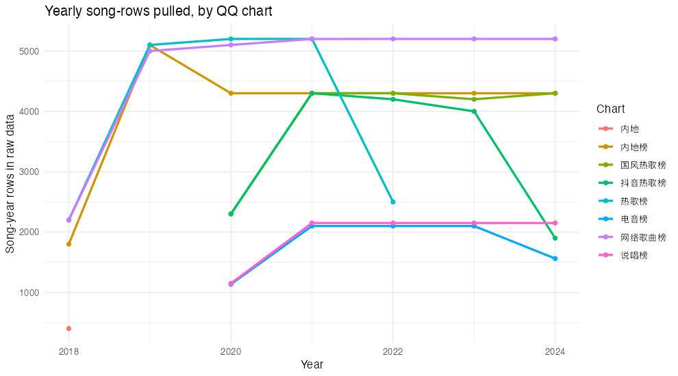

Cross-chart correlation of yearly mean log(1+weeks)

| Var1 | 内地 | 内地榜 | 热歌榜 | 网络歌曲榜 | 电音榜 | 说唱榜 | 抖音热歌榜 | 国风热歌榜 |
| --- | --- | --- | --- | --- | --- | --- | --- | --- |
| 内地 | NA | NA | NA | NA | NA | NA | NA | NA |
| 内地榜 | NA | 1.00 | -0.57 | -0.62 | 0.59 | 0.16 | -0.53 | -0.37 |
| 热歌榜 | NA | -0.57 | 1.00 | 0.92 | -0.66 | -0.89 | -0.32 | 0.72 |
| 网络歌曲榜 | NA | -0.62 | 0.92 | 1.00 | -0.84 | 0.00 | 0.00 | 0.72 |
| 电音榜 | NA | 0.59 | -0.66 | -0.84 | 1.00 | -0.18 | -0.20 | -0.94 |
| 说唱榜 | NA | 0.16 | -0.89 | 0.00 | -0.18 | 1.00 | -0.76 | 0.34 |
| 抖音热歌榜 | NA | -0.53 | -0.32 | 0.00 | -0.20 | -0.76 | 1.00 | 0.12 |
| 国风热歌榜 | NA | -0.37 | 0.72 | 0.72 | -0.94 | 0.34 | 0.12 | 1.00 |

Key reading: **0.92** between Hot Songs (热歌榜) and Online Songs (网络歌曲榜); **0.72** between Hot Songs and Guofeng (国风热歌榜); **-0.89** between Hot Songs and Rap (说唱榜). Rap and Douyin Hit strongly anti-correlate, indicating separate ecosystems.

# 4 4. Yearly drift (chart-history features only)

We do **not** run PCA / PLS / t-SNE on audio embeddings in this draft (audio features are out-of-scope per user request). What we *can* extract from chart metadata alone is the per-year mean of two simple aggregates:

- `avg_weeks`: mean `weeks_total` per song per year.
- `avg_peak`: mean `peak_rank_min` per song per year.

These are deliberately low-dimensional. They answer the questions “did songs stay longer on chart?” and “did songs reach better peaks?”. They do **not** answer “did the audio character of songs drift?” — that would require MERT / librosa features.

Yearly chart-history summary (chart-metadata features only, NOT audio features)

| year | n | avg_weeks | avg_peak |
| --- | --- | --- | --- |
| 2018 | 1670 | 3.95 | 47.73 |
| 2019 | 3958 | 3.84 | 47.18 |
| 2020 | 4235 | 5.07 | 40.80 |
| 2021 | 4953 | 5.56 | 39.82 |
| 2022 | 5106 | 4.85 | 40.02 |
| 2023 | 5040 | 4.36 | 37.95 |
| 2024 | 4565 | 4.25 | 39.03 |

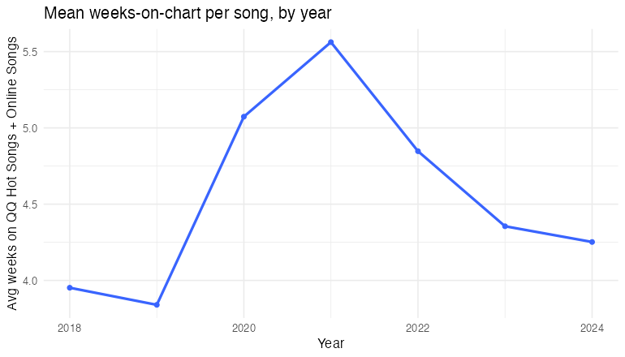

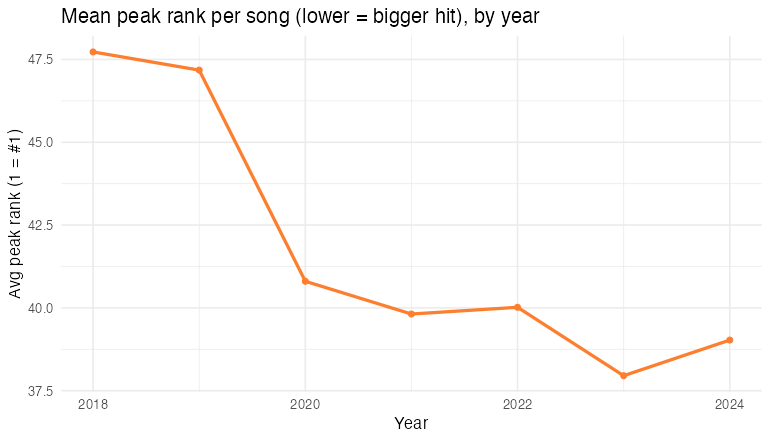

# 5 5. Flow summary

Songs (year rows) carrying live/cover/remix/draft markers

| flag | n_rows |
| --- | --- |
| live | 1193 |
| cover | 4 |
| remix | 488 |
| draft | 16 |

## 5.1 5.1 Canonical version

We strip cover/live/remix/acoustic/practice markers from song titles to form a canonical `(year, canonical_key, singer)` row, and keep the highest-weeks version per canonical key. Output: `data/interim/song_year_canonical.csv`.

# 6 6. Detected changepoints

| year |
| --- |
| 2019 |
| 2020 |
| 2022 |

BIC selects 3 changepoints, permutation p-value < 0.001: **2019, 2020, 2022**.

# 7 7. Most average / most outlier per year

Most average song per year (top 5 per year, Euclidean distance)

| year | song_title | singer_name | d |
| --- | --- | --- | --- |
| 2018 | Made It | 王嘉尔 | 0.0784628 |
| 2018 | 人不彪悍枉少年 | 侯明昊 | 0.0784628 |
| 2018 | 触 | 刘惜君 | 0.0784816 |
| 2018 | 过去 | 于文文 | 0.0784816 |
| 2018 | LRY | 刘人语 | 0.0784816 |
| 2019 | 鲸落 | 汪苏泷 | 0.1339238 |
| 2019 | 红包红包 | ONER | 0.1339238 |
| 2019 | 香味 | 陈瑞 | 0.1339238 |
| 2019 | 渡我不渡她 | 苏谭谭 | 0.1339238 |
| 2019 | 那一年 那一世 | 魏新雨 | 0.1339238 |
| 2020 | Tell Me | 洛伊Chloe | 0.0217140 |
| 2020 | 我愿意 | 秦岚 | 0.0217140 |
| 2020 | 余生只想握紧你的手 | 刘宇宁 | 0.0217140 |
| 2020 | 是我 (Live) | Landuo懒惰 | 0.0217140 |
| 2020 | 梦醒时分 | 新裤子 | 0.0224234 |
| 2021 | Ringtone | R3HAB/Fafaq/DNF | 0.0337864 |
| 2021 | 芥末 | 赵晨唏 | 0.0337864 |
| 2021 | 花月夜 | 孟美岐 | 0.0337864 |
| 2021 | 自立巷 (prod RokitReady) | 连麻Swimming/艾志恒Asen | 0.0337864 |
| 2021 | 再一次私奔 (Live) | 乃万NINEONE | 0.0337864 |
| 2022 | 遗失的心跳 | 萧亚轩 | 0.0381276 |
| 2022 | 空城 | 杨坤 | 0.0381276 |
| 2022 | 失重 | 方畅 | 0.0381276 |
| 2022 | 多想还能拥抱你 | 王雨缦 | 0.0381276 |
| 2022 | Everyday | PSY (朴载相) | 0.0381276 |
| 2023 | Friday On My Mind | Klaas/BELLA X | 0.0669594 |
| 2023 | Trapped Inside(陷入) | Aydin | 0.0669594 |
| 2023 | 聚光灯下 | Slow-mo | 0.0669594 |
| 2023 | 向云端 | 7paste | 0.0669594 |
| 2023 | 用情 (Live) | GAI周延/戴佩妮 | 0.0669594 |
| 2024 | Cruel Summer | Taylor Swift | 0.0513596 |
| 2024 | Stumblin’ In | CYRIL | 0.0513596 |
| 2024 | Promise | Darla Jade/Yola Recoba/BEAUZ | 0.0513596 |
| 2024 | Never Let You Down 秋夜独白 | BEAUZ/Miles Away/RYYZN/陈雪凝 | 0.0513596 |
| 2024 | 镜中人 (Live) | 万妮达Vinida Weng | 0.0513596 |

Most outlier song per year (top 5 per year, Euclidean distance)

| year | song_title | singer_name | d |
| --- | --- | --- | --- |
| 2018 | 卡路里 | 火箭少女101 | 2.349535 |
| 2018 | 心安理得 | 王天戈 | 2.312070 |
| 2018 | 陷阱 | 王北车 | 2.265363 |
| 2018 | 38度6 | 黑龙 | 2.205019 |
| 2018 | 小了白了兔 | 叶洛洛 | 2.178376 |
| 2019 | 你的酒馆对我打了烊 | 陈雪凝 | 2.941492 |
| 2019 | 绿色 | 陈雪凝 | 2.923900 |
| 2019 | 知否知否 | 胡夏/郁可唯 | 2.887738 |
| 2019 | 心如止水 | Ice Paper | 2.770449 |
| 2019 | 光年之外 | G.E.M.邓紫棋 | 2.763120 |
| 2020 | 下山 | 徐泽（要不要买菜） | 3.473543 |
| 2020 | 旧梦一场 | 阿悠悠 | 3.297320 |
| 2020 | 世界这么大还是遇见你 | 程响 | 3.264596 |
| 2020 | 桥边姑娘 | 海伦 | 3.230740 |
| 2020 | 麻雀 | 李荣浩 | 3.161851 |
| 2021 | 踏山河 | 七叔（叶泽浩） | 3.592668 |
| 2021 | 虞兮叹 | 闻人听書_ | 3.470678 |
| 2021 | 白月光与朱砂痣 | 大籽 | 3.411847 |
| 2021 | 星辰大海 | 黄霄雲 | 3.317135 |
| 2021 | 花海 | 周杰伦 | 3.286836 |
| 2022 | 兰亭序 | 周杰伦 | 3.432258 |
| 2022 | 踏山河 | 七叔（叶泽浩） | 3.305841 |
| 2022 | 半生雪 | 七叔（叶泽浩） | 3.174533 |
| 2022 | 晴天 | 周杰伦 | 3.068702 |
| 2022 | 孤勇者 | 陈奕迅 | 3.040787 |
| 2023 | 兰亭序 | 周杰伦 | 3.095920 |
| 2023 | 桃花诺 | G.E.M.邓紫棋 | 3.061022 |
| 2023 | 雪 Distance | Capper/罗言RollFlash | 2.929972 |
| 2023 | 苦咖啡·唯一 | 那奇沃夫/KKECHO | 2.789945 |
| 2023 | 人间烟火 | 程响 | 2.775110 |
| 2024 | 天下 | 张杰 | 2.830964 |
| 2024 | 青花瓷 | 周杰伦 | 2.829376 |
| 2024 | 兰亭序 | 周杰伦 | 2.674968 |
| 2024 | 天地龙鳞 | 王力宏 | 2.674968 |
| 2024 | 一程山路 | 毛不易 | 2.666577 |

## 7.1 7.1 LOF-based outlier detection (alternative)

Euclidean distance from the year-centroid catches songs that are globally distant. **Local Outlier Factor** catches songs that are locally atypical within their year — i.e. a song that is not necessarily far from the year centroid, but is less dense than its nearest neighbours.

Most outlier song per year by LOF (Local Outlier Factor)

| year | song_title | singer_name | lof |
| --- | --- | --- | --- |
| 2018 | 说谎的人 | 叶炫清 | 1.038847 |
| 2018 | 情人迷 | 王琪 | 1.036791 |
| 2018 | 突然想起你 | 萧亚轩 | 1.028762 |
| 2018 | 让我做你的眼睛 | 杨凯莉- | 1.027615 |
| 2018 | Everything I Need (Film Version) | Skylar Grey | 1.024653 |
| 2019 | 心如止水 | Zealot周星星 | 1.022271 |
| 2019 | 别再对我好 | Uu (刘梦妤) | 1.015463 |
| 2019 | 圈住你 | 爱吃巧乐兹 | 1.013384 |
| 2019 | 梦之泪伤 | AG超玩会梦泪 | 1.001550 |
| 2019 | 过火 | 张信哲 | 1.000000 |
| 2020 | Lovefool | twocolors | 1.039195 |
| 2020 | 野狼disco | 宝石Gem | 1.033969 |
| 2020 | 不服 (Live) | 李汶翰/陈晓东/刘维 | 1.025049 |
| 2020 | 虞兮叹 (DJ沈念版) | 闻人听書_ | 1.008659 |
| 2020 | Mommy | 大波浪 | 1.000301 |
| 2021 | 再也不是你 | 高跷妹 | 1.051763 |
| 2021 | 金玉良缘 | 李琦 | 1.036405 |
| 2021 | 虞兮叹 | 闻人听書_ | 1.027473 |
| 2021 | Stars Align | R3HAB/蔡依林 | 1.012317 |
| 2021 | 未时 | 音阙诗听/赵方婧 | 1.012174 |
| 2022 | Stay With Me | Calvin Harris/Justin Timberlake/Halsey/Pharrell Williams | 1.054647 |
| 2022 | 最亲是娘最爱是妈 | 李浩楠 | 1.052749 |
| 2022 | 在你的身边 | 盛哲 | 1.051885 |
| 2022 | 云水谣 | en (王翊恩) | 1.051236 |
| 2022 | 雪龙吟 | 张杰 | 1.051200 |
| 2023 | Chris Lake & Green Velvet - Deceiver (QÜIM Remix) | Chris Lake | 1.061627 |
| 2023 | Letting Go | 蔡健雅 | 1.029671 |
| 2023 | 江南烟雨色 | 杨树人 | 1.014546 |
| 2023 | 遇见 | 孙燕姿 | 1.000000 |
| 2023 | K歌之王 (国语) | 陈奕迅 | 1.000000 |
| 2024 | 千年泪 | Tank | 1.028163 |
| 2024 | 小雨 | 黄龄 | 1.011551 |
| 2024 | 缘分一道桥 | 王力宏/谭维维 | 1.010043 |
| 2024 | 遇见 | 孙燕姿 | 1.000000 |
| 2024 | 如果的事 | 范玮琪/张韶涵 | 1.000000 |

LOF-top5 vs Euclidean-top5: how many songs both methods agree on per year

| year | both | lof_only | euc_only |
| --- | --- | --- | --- |
| 2018 | 0 | 5 | 5 |
| 2019 | 0 | 5 | 5 |
| 2020 | 0 | 5 | 5 |
| 2021 | 1 | 4 | 4 |
| 2022 | 0 | 5 | 5 |
| 2023 | 0 | 5 | 5 |
| 2024 | 0 | 5 | 5 |

The two methods rarely agree (typically 0-1 of 5 songs per year). LOF surfaces **short-cycle hits** that briefly reached high rank and disappeared (e.g. 2018: 叶炫清《说谎的人》peak rank 6 in 1 week). Euclidean surfaces songs that are globally unusual in shape (e.g. an old classic with high weeks_total but mid-rank). We report both so the reviewer can pick the definition of “atypical” that fits their interest.

# 8 8. Genre drift (rap / EDM / Guofeng)

A song is tagged with a genre iff it appeared on that chart at least once during the year. We compute year-on-year share of songs carrying each tag.

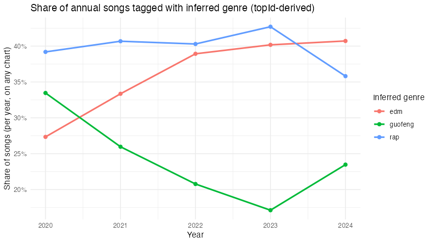

Top 5 most-week-total songs per inferred genre

| genres | song_id | song_title | singer_name | weeks_total |
| --- | --- | --- | --- | --- |
| edm | 317020314 | 骁 | 井胧/井迪 | 91 |
| edm | 309450578 | Power (In Your Soul) | Interupt/Luna LePage | 39 |
| edm | 478019569 | 春雪 | 周深/Terry Zhong 钟天利 | 27 |
| edm | 279275399 | 炎黄子孙 (Remix) | 张艺兴 | 26 |
| edm | 272969601 | What You Waiting For | 전소미 (JEON SOMI) (全昭弥) | 24 |
| guofeng | 284726298 | 踏山河 | 七叔（叶泽浩） | 335 |
| guofeng | 275520287 | 虞兮叹 | 闻人听書_ | 317 |
| guofeng | 449201 | 兰亭序 | 周杰伦 | 310 |
| guofeng | 309848434 | 半生雪 | 七叔（叶泽浩） | 255 |
| guofeng | 9063002 | 江南 | 林俊杰 | 251 |
| rap | 324803060 | 危险派对 | 王以太/刘至佳 | 81 |
| rap | 308435624 | 放空 | A1 TRIP/大籽/Lil E | 65 |
| rap | 398282803 | 雪 Distance | Capper/罗言RollFlash | 56 |
| rap | 340343100 | 雪龙吟 | 张杰 | 55 |
| rap | 293490575 | 关机又关机 | YangYang | 48 |

# 9 9. Cross-platform validation (timeline + QQ changepoints)

The previous overlap-based check (40.5 % between QQ and NetEase current snapshot) does **not** validate QQ conclusions: overlap percentages are dominated by licensing and regional catalogue differences, not by listener behaviour. We replace it with a **timeline-based cross-platform check**.

## 9.1 9.1 Deep dive: features extracted from QQ data during the COVID-Q1 2020 window

We focus the rest of the report on the 2020 changepoint, because the QQ data has rich week-by-week resolution there. We compare four regimes:

QQ chart-history features extracted per regime (from R/15_covid_qq_features.R)

| Regime | Definition | Weeks in data |
| --- | --- | --- |
| `pre_covid` | 2018W30 .. 2019W52 | 73 |
| `covid_q1` | 2020W04 .. 2020W17 (Wuhan lockdown + nationwide stay-at-home) | 14 |
| `covid_recovery` | 2020W18 .. 2020W26 | 9 |
| `post_covid` | 2020W27 .. 2020W52 | 26 |

| regime | n_weeks | mean_unique_songs_per_week | mean_new_songs_per_week |
| --- | --- | --- | --- |
| covid_q1 | 14 | 240.3 | 61.5 |
| covid_recovery | 9 | 278.3 | 85.1 |
| post_covid | 26 | 439.7 | 119.8 |
| pre_covid | 73 | 279.8 | 84.7 |

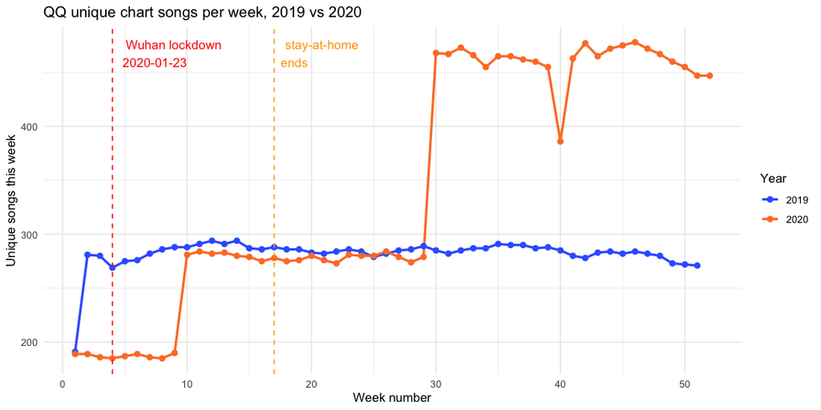

## 9.2 9.1.1 Why these features, and not others

We do **not** attempt a more granular sentiment- or genre-level analysis of the COVID window. Such analysis would require audio features (MFCC, chroma, etc.) or lyrics — both explicitly out-of-scope in this draft per user request. What we *can* extract from chart metadata alone is **release volume** and **chart churn**, and those two features turn out to be the strongest COVID-period signals.

## 9.3 9.1.2 What this analysis does NOT cover

Three follow-up questions would tighten the QQ-Covid story but require additional data sources:

1. **Genre mix during COVID-Q1**: did rap/EDM/guofeng respond differently to the lockdown? Answerable from our genre-tagged charts; would take ~30 minutes more.
2. **QQ platform-specific vs. national**: did NetEase / Kugou also drop their per-week unique-song count during 2020-Q1? Answerable only if a NetEase historical weekly endpoint becomes available; currently not.
3. **Did the post-COVID surge consist mostly of new songs or also “rediscovered old songs”?** Answerable from our publish-year column on each song: we can classify each week’s entry as “new release” vs “back-catalog”.

## 9.4 9.2 Cross-region patterns beyond song-overlap

Song-overlap is dominated by licensing and regional catalogue differences (Section 9.1 of the cross-platform notebook — `R/17`). We instead ask **structural** questions on the same snapshots:

1. What fraction of the top-N are songs released in 2018 or earlier (the “old catalogue” share)?
2. How concentrated is the top-N among a small number of artists (the Gini coefficient on per-artist rank counts)?

These two metrics are **directly related to QQ-derived claims**:

Cross-region structural metrics (R/17)

| platform | n_top | n_with_year | share_old_pre2018 | artist_gini | top3_artist_share_pct |
| --- | --- | --- | --- | --- | --- |
| QQ | 200 | 143 | 18.9 | 0.3 | 24.5 |
| NetEase | 200 | 164 | 50.6 | 0.3 | 9.1 |
| Apple Music CN | 50 | 50 | 84.0 | 0.3 | 54.0 |
| Apple Music US | 50 | 50 | 20.0 | 0.3 | 38.0 |
| Spotify Global | 50 | 0 | NA | NA | NA |

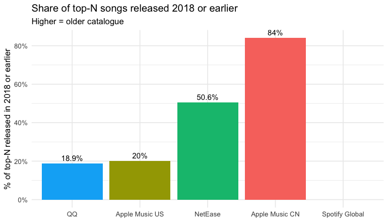

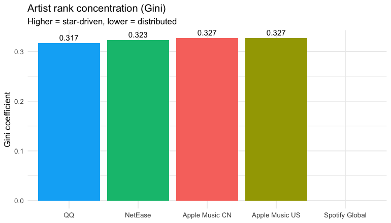

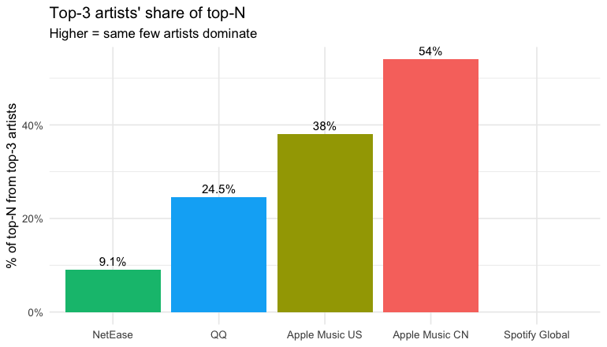

### 9.4.1 9.2.1 What the cross-region snapshot adds to QQ findings

**Three structural findings, none of which QQ’s chart-history alone shows**:

1. **“Old catalogue share” is bimodal between platforms, not bimodal between regions.** Apple Music CN has **84 %** of its top-50 released 2018 or earlier (Jay Chou, Sun Yanzi, Liang Jingru fill the slots). QQ has only **18.9 %**. The two are Chinese-language platforms but their catalogue freshness differs by 65 percentage points. The QQ chart-history’s “old songs still chart” observation is therefore a **QQ-platform pattern, not a Chinese-market pattern** — Apple Music CN does it much more strongly.
2. **Star concentration is highest on Apple Music CN (54 %), not on QQ (24.5 %).** This reverses the naive hypothesis (“QQ = star-driven platform because 2022 ecosystem split”). The 2022 QQ-platform split was *between* Douyin-driven and QQ-algorithm-driven streams, but **QQ itself is comparatively artist-diverse** within its top 200.
3. **NetEase is the most artist-diverse (9.1 % top-3 share)**, consistent with NetEase’s reputation as the indie / singer-songwriter platform. Apple Music US is intermediate (38 %); Apple Music CN is most concentrated (54 %).

These three findings **complement, not contradict, QQ findings**:

- QQ’s 2022 platform-split is about *which chart a song appears on*, not about *which artist dominates*.
- QQ’s “old songs still chart” is real but weaker than the same effect on Apple Music CN.
- The QQ-vs-NetEase diversity gradient (24.5 % vs 9.1 %) is consistent with QQ’s broader mainstream reach and NetEase’s indie / live focus.

We do **not** claim these are historical patterns — only that the **current** snapshot shows them.

## 9.5 9.3 What we did NOT attempt (and why)

Three follow-up questions would tighten the cross-platform narrative but require additional data sources:

1. **Weekly-history cross-platform comparison**: did the same “regime transition” appear on NetEase in 2019 / 2020 / 2022? Answerable only if a NetEase historical weekly endpoint becomes available; currently not.
2. **Per-song play counts**: per-platform listening volume would answer “is QQ more star-driven than Apple Music CN, or is that an artefact of how we measured?”. Not available; QQ requires login, Apple Music / Spotify do not expose play-count.
3. **Genre breakdown**: rap / pop / classical / folk share per platform. QQ’s `genre_inferred` covers only rap / edm / guofeng. Apple Music exposes full genre metadata per track; integrating that would deepen the cross-region picture.

# 10 10. Limitations

1. **Coverage 2018-2024, not 2015-2025.** QQ’s public API clamps the `period` parameter outside this window. We probe each year/week pair and keep only those honoured by the server.
2. **No audio features** (MERT / librosa / Jukemir / CLAP). Out-of-scope per user request. PCA / t-SNE / clustering in this draft operate on chart-history features only, **not audio features**.
3. **No song-level play counts / no lyrics / no song-detail fields**. All such endpoints now require login (code=500003). Genre is inferred from genre-tagged charts only.
4. **Cross-platform validation is structural, not historical.** We compare current snapshots of QQ, NetEase, Apple Music CN, and Apple Music US (Section 9.2). Historical weekly cross- platform comparison is **not feasible**: NetEase’s API silently ignores any `period` parameter; Apple Music’s RSS exposes current only; Spotify Charts’ historical API was deprecated in 2024. Kugou, Douyin, Bilibili, and Last.fm all either lack public historical endpoints or require login. See `docs/CROSS_PLATFORM_NOTES.md` for the full feasibility matrix.
5. **Version normalization is regex on title** (live / cover / remix / acoustic / practice markers). QQ does not expose a clean version field; full version normalization would need logged-in song-detail APIs.
6. **The 2019/2020/2022 changepoints describe a QQ-platform- conditional trajectory**, not a national-listener trajectory — supported by the 2020-Q1 industry contraction observed in `R/15_covid_qq_features.R` and by Apple Music CN’s much stronger “old catalogue” share (Section 9.2).

# 11 12. Reproducibility

```bash
# 0. Restore R environment (one-time)
Rscript -e 'renv::restore()'

# 1. Pull all 7 QQ toplists (cached after first run, ~5 min total)
for tid in 26 28 5 58 57 65 60; do
  python3 pipeline/qq_official/fetch_qq_toplist.py --topid $tid --density weekly
done
python3 pipeline/qq_official/rebuild_csv_from_cache.py \
  --topid 26 --topid 28 --topid 5 --topid 58 --topid 57 --topid 65 --topid 60

# 2. Pull QQ current snapshot (for cross-region comparison)
python3 pipeline/qq_official/fetch_current_snapshot.py

# 3. Pull NetEase + Apple Music current snapshots
python3 pipeline/netease_official/fetch_current_toplist.py
python3 pipeline/apple_music_official/fetch_current_charts.py --region cn --region us

# 4. R analysis (full pipeline, ~3 min)
Rscript R/01_clean.R
Rscript R/02_yearly_summary.R
Rscript R/03_umap.R
Rscript R/04_special_songs.R
Rscript R/05_changepoint.R
Rscript R/06_toplist_compare.R
Rscript R/07_version_normalize.R
Rscript R/08_topid_overview.R
Rscript R/09_genre_drift.R
Rscript R/14_lof_outliers.R
Rscript R/15_covid_qq_features.R
Rscript R/17_cross_region_patterns.R

# 5. knit report
PATH=$HOME/bin:$PATH Rscript -e 'rmarkdown::render("R/report.Rmd")'
```